# NosAnalizamos

María Martínez Marí

2026-05-16

# Carga de las librerías:

```r
library(tidyverse)
```

```r
library(dplyr)
library(ggplot2)
library(lubridate)
library(pacman)
library(readr)
library(stringr)
```

# Cargar el fichero de datos a un data frame.

```r
# o read.delim()
fich<- read_tsv("data/NosAutoanalizamos2022 - Hoja1.tsv")
```

```
## ──────────────────────────────────────────────────────── Delimiter: "\t" chr
## (21): 8-6-2002, ...2, ...3, ...4, Fecha, Fecha de nacimiento en formato ...
```

```r
da<-as.data.frame(fich)
head(da, 3)
```

```
##    8-6-2002 ...2 ...3 ...4          Fecha
## 1  sercama3 <NA>   .. <NA> Identificación
## 2        19 <NA> <NA> <NA>            Age
## 3 Masculino <NA> <NA> <NA>            Sex
##   Fecha de nacimiento en formato dd-mm-yyyy ...7 ...8 ...9 ...10 ...11 ...12
## 1            Usuario de correo UV. martsobm <NA> <NA> <NA>  <NA>  <NA>  <NA>
## 2                             Edad en años. <NA> <NA> <NA>  <NA>  <NA>  <NA>
## 3                 Sexo: Femenino, Masculino <NA> <NA> <NA>  <NA>  <NA>  <NA>
##   ...13 ...14 ...15 ...16 ...17 ...18 ...19 ...20 ...21
## 1  <NA>  <NA>  <NA>  <NA>  <NA>  <NA>  <NA>  <NA>  <NA>
## 2  <NA>  <NA>  <NA>  <NA>  <NA>  <NA>  <NA>  <NA>  <NA>
## 3  <NA>  <NA>  <NA>  <NA>  <NA>  <NA>  <NA>  <NA>  <NA>
```

```r
# El df contendrá las columnas con variables y las filas que contengan datos.
# Vemos que el nombre de las columnas están en la fila 24:

# Seleccionamos desde la fila 25 hasta el final:
datos<- da[24:nrow(da),]
colnames(datos)<- datos[1,]
datos<-datos[-1,] #Quitamos la fila 24

datos <- datos %>%
  rename(Registro = 1)  # Esto cambia la columna 1 por "Registro"


head(datos, 5)
```

```
##            Registro FechaNac(DD-MM-YYY)       Id Age Sex Wr.Hnd    NW.Hnd
## 25 Registro Ejemplo          20-01-1969 martsobm  53   M     22   Derecha
## 26             <NA>          18-11-2003   pedelu  18   M     18   Derecha
## 27             <NA>          19-08-2003   salgis  18   M     19   Derecha
## 28             <NA>          15-03-2003   garfal  18   F     18 Izquierda
## 29             <NA>          24-06-2003  silobor  18   F     18   Derecha
##         Fold Pulse      Clap Exer Smoke Height ALG  ANM   FP  DCS   MD HSt
## 25 Izquierdo    65 Der s Izq    2    No    178  NP    7    6    4  3.8   5
## 26 Izquierdo    50 Der s Izq    5    No    180  10 9.62   NP  8.3  9.3 1.5
## 27   Derecho    73 Der s Izq    0    No    173 2.8    4 <NA> 5.11 5.55   2
## 28 Izquierdo    71 Der s Izq    0    No    163 6.4 6.65 <NA>  6.5  5.8   3
## 29   Derecho    66 Der s Izq    0    No    164 7.1  7.8 <NA>  7.5    7   3
##    Hwork
## 25  37,5
## 26    10
## 27     0
## 28     8
## 29     1
##                                                                                      Comentarios
## 25 Es la primera toma de contacto con el análsis de datos reales. Me resultará de gran utilidad.
## 26                                         Continuación de DCS pero menos teórico y más práctico
## 27                                                                           Parece interesante.
## 28                                          Seguimiento de DCS, pero parece un poco más práctico
## 29                                                                       Parece denso y complejo
```

# 4. Eliminamos el usuario cuyo id es martsobm:

```r
datos_final <- datos %>%
  filter(Id != "martsobm")

head(datos_final)
```

```
##   Registro FechaNac(DD-MM-YYY)       Id Age Sex Wr.Hnd    NW.Hnd      Fold
## 1     <NA>          18-11-2003   pedelu  18   M     18   Derecha Izquierdo
## 2     <NA>          19-08-2003   salgis  18   M     19   Derecha   Derecho
## 3     <NA>          15-03-2003   garfal  18   F     18 Izquierda Izquierdo
## 4     <NA>          24-06-2003  silobor  18   F     18   Derecha   Derecho
## 5     <NA>           21-6-2003 jamarlli  18   M     16   Derecha   Derecho
## 6     <NA>          13-05-2003  mabalo3  18   M     20 Izquierda Izquierdo
##   Pulse      Clap Exer Smoke Height ALG  ANM   FP  DCS   MD HSt Hwork
## 1    50 Der s Izq    5    No    180  10 9.62   NP  8.3  9.3 1.5    10
## 2    73 Der s Izq    0    No    173 2.8    4 <NA> 5.11 5.55   2     0
## 3    71 Der s Izq    0    No    163 6.4 6.65 <NA>  6.5  5.8   3     8
## 4    66 Der s Izq    0    No    164 7.1  7.8 <NA>  7.5    7   3     1
## 5    60 Der s Izq    4    No    180 9.5  9.2  9.5  9.0  9.4   5     3
## 6    96 Izq s Der    6    No    175 1.9  3.4 <NA>  5.2  2.2   1     0
##                                                                                                                                                                                                                                                                   Comentarios
## 1                                                                                                                                                                                                                       Continuación de DCS pero menos teórico y más práctico
## 2                                                                                                                                                                                                                                                         Parece interesante.
## 3                                                                                                                                                                                                                        Seguimiento de DCS, pero parece un poco más práctico
## 4                                                                                                                                                                                                                                                     Parece denso y complejo
## 5                                                                                                                                                                                                                                                           Tiene buena pinta
## 6 Antes que nada tengo que saber bien de qué trata la asignatura porque de momento no la entiendo muy bien pero sé que es muy importante para mi futuro en la carrera por todos los temas que se dan y que creo que es una base de todo en lo que nos estamos especializando.
```

# 5. Seleccionar las columas con las calificaciones y adecúalas.

```r
# Separador decimal es el punto.
# Si alguna calificación es NC se sustituirá por 3.
# Valor no conocido se sustituirá por NA

# Creamos el vector con el nombre de las columnas que contienen las calificaciones.
variables_notas <- c("ALG","ANM","FP","DCS","MD")


# Vemos que de las columnas 14 a la 20 son notas
notas <- datos_final %>%
  # mutate() Modificamos las columnas
  # across() se aplica en varias columnas la misma operacion
  # all_of () que trabajamos solo con esas asignaturas.
  # ifelse(condicion, valor si sí, valor sino)
  # El primer punto significa todas las columnas
  # El tercer punto indica que se quede como está
  # ~ este símbolo indica que ahora viene una función
  mutate(across(all_of(variables_notas),
                ~ ifelse(. == "NC", "3", .))) %>%

  # Expresión regular: Permite números como 5, 7.2 etc.

  mutate(across(all_of(variables_notas),
                ~ ifelse(str_detect(., "^[0-9]+(\\.[0-9]+)?$"), ., NA))) %>%

  # convertir a numérico

  mutate(across(all_of(variables_notas), as.numeric))

head(notas)
```

```
##   Registro FechaNac(DD-MM-YYY)       Id Age Sex Wr.Hnd    NW.Hnd      Fold
## 1     <NA>          18-11-2003   pedelu  18   M     18   Derecha Izquierdo
## 2     <NA>          19-08-2003   salgis  18   M     19   Derecha   Derecho
## 3     <NA>          15-03-2003   garfal  18   F     18 Izquierda Izquierdo
## 4     <NA>          24-06-2003  silobor  18   F     18   Derecha   Derecho
## 5     <NA>           21-6-2003 jamarlli  18   M     16   Derecha   Derecho
## 6     <NA>          13-05-2003  mabalo3  18   M     20 Izquierda Izquierdo
##   Pulse      Clap Exer Smoke Height  ALG  ANM  FP  DCS   MD HSt Hwork
## 1    50 Der s Izq    5    No    180 10.0 9.62  NA 8.30 9.30 1.5    10
## 2    73 Der s Izq    0    No    173  2.8 4.00  NA 5.11 5.55   2     0
## 3    71 Der s Izq    0    No    163  6.4 6.65  NA 6.50 5.80   3     8
## 4    66 Der s Izq    0    No    164  7.1 7.80  NA 7.50 7.00   3     1
## 5    60 Der s Izq    4    No    180  9.5 9.20 9.5 9.00 9.40   5     3
## 6    96 Izq s Der    6    No    175  1.9 3.40  NA 5.20 2.20   1     0
##                                                                                                                                                                                                                                                                   Comentarios
## 1                                                                                                                                                                                                                       Continuación de DCS pero menos teórico y más práctico
## 2                                                                                                                                                                                                                                                         Parece interesante.
## 3                                                                                                                                                                                                                        Seguimiento de DCS, pero parece un poco más práctico
## 4                                                                                                                                                                                                                                                     Parece denso y complejo
## 5                                                                                                                                                                                                                                                           Tiene buena pinta
## 6 Antes que nada tengo que saber bien de qué trata la asignatura porque de momento no la entiendo muy bien pero sé que es muy importante para mi futuro en la carrera por todos los temas que se dan y que creo que es una base de todo en lo que nos estamos especializando.
```

```r
saveRDS(notas, "Notas.Rdata")
```

# 6. Obtener una tabla de estadísticos de estas variables.

Primera columna las asignaturas y las siguientes asignaturas que correspondan con los estadísticos.

```r
est <- notas[, 14:18]

tabla_est <- data.frame(
  Asignatura = names(est),
  # con sapply() aplicamos una funcion a cada columna y devuelve el resultado
  Minimo = sapply(est, min, na.rm = TRUE),
  P25 = sapply(est, quantile, probs = 0.25, na.rm = TRUE),
  Mediana = sapply(est, median, na.rm = TRUE),
  Media = sapply(est, mean, na.rm = TRUE),
  DesvTipica = sapply(est, sd, na.rm = TRUE),
  P75 = sapply(est, quantile, probs = 0.75, na.rm = TRUE),
  Maximo = sapply(est, max, na.rm = TRUE)
)

tabla_est <- tabla_est %>%
  mutate(across(where(is.numeric), ~ round(.x, 2)))


tabla_est
```

```
##     Asignatura Minimo  P25 Mediana Media DesvTipica  P75 Maximo
## ALG        ALG    1.9 6.00    6.72  6.41       1.65 7.50  10.00
## ANM        ANM    3.4 6.97    7.90  7.61       1.45 8.50   9.81
## FP          FP    3.0 3.53    6.00  5.77       2.25 7.25   9.50
## DCS        DCS    3.0 6.79    7.65  7.42       1.36 8.30   9.80
## MD          MD    1.5 5.47    6.40  6.12       1.99 7.41   9.50
```

# 7. la función ggpairs de la librería GGally y representa las relaciones entre todas las variables.

```r
library(GGally)
```

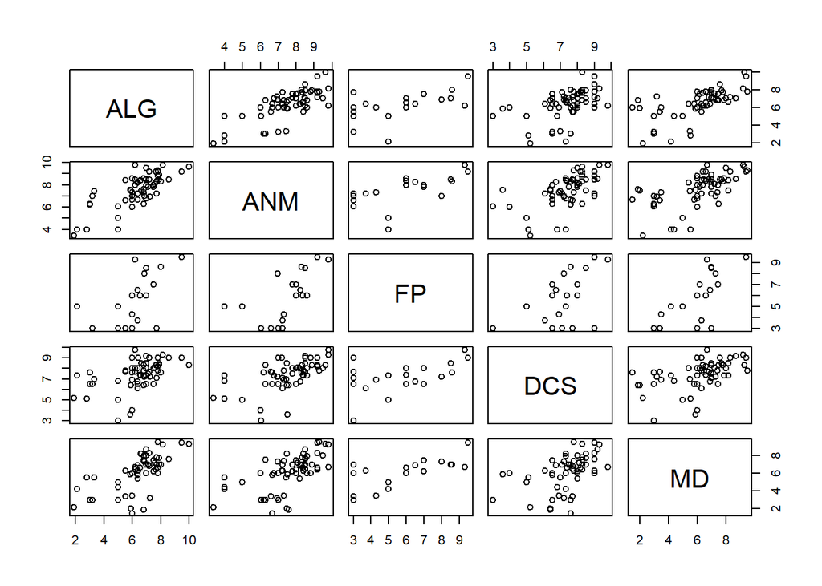

```r
est %>% pairs()
```

#8. Determina las matrices de correlación y covarianza de dichas variables, con las opciones “Spearman” y “Pearson” e indica qué pares de variables tienen la correlación más alta.

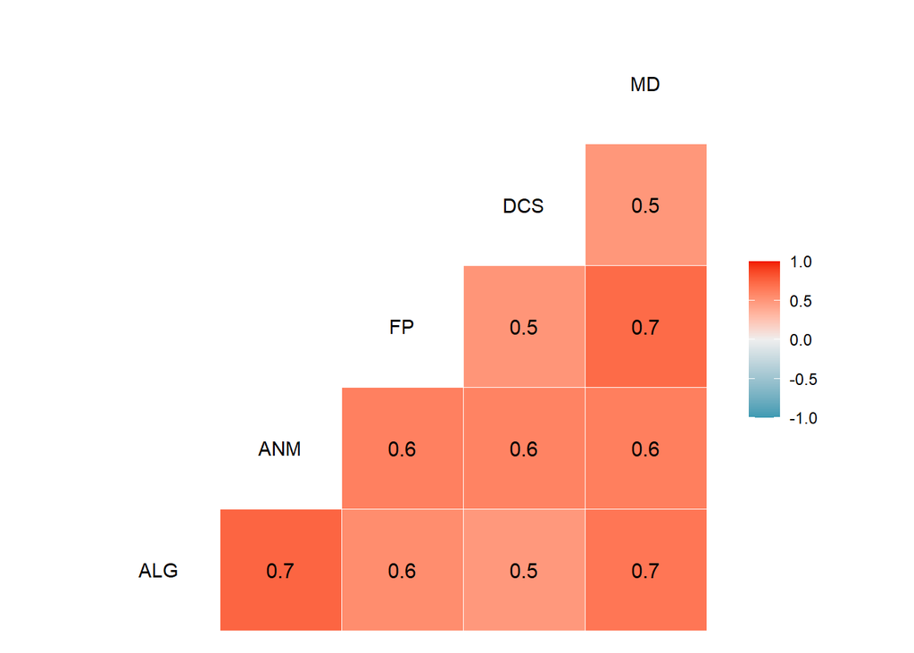

```r
# Matriz de correlación
est %>% ggcorr(label = TRUE)
```

```r
# Vemos que el par de variables que tienen una mayor correlación es FP con MD, MD y ALG y ALG con ANM.


# Matriz de covarianza:
cov(est, use= "complete.obs") %>% round(2)
```

```
##      ALG  ANM   FP  DCS   MD
## ALG 2.68 1.58 2.03 0.81 2.23
## ANM 1.58 1.86 1.89 1.13 1.45
## FP  2.03 1.89 5.08 1.70 2.77
## DCS 0.81 1.13 1.70 2.22 1.27
## MD  2.23 1.45 2.77 1.27 2.90
```

# 9. Representa en una misma gráfica los boxplots con las calificaciones obtenidas en las diferentes asignaturas.

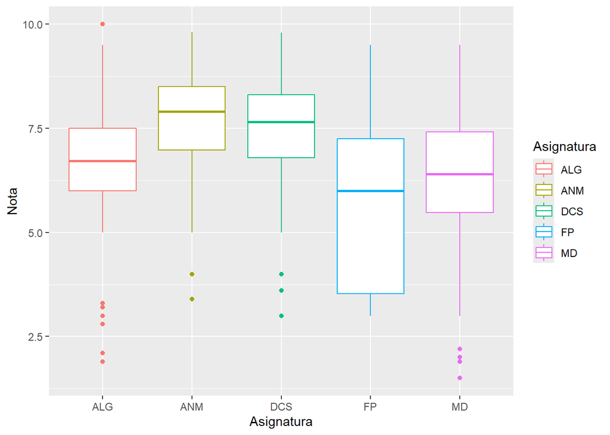

```r
Asignatura_Nota<-pivot_longer(est, cols= names(est),
               names_to= "Asignatura",
               values_to= "Nota")

Asignatura_Nota%>%
  ggplot(aes(x=Asignatura, y=Nota, color= Asignatura)) + geom_boxplot()
```

# 10. Añade la variable sexo al conjunto de datos y realiza la representación del boxplot de calificaciones por asignatura coloreando según dicha variable.

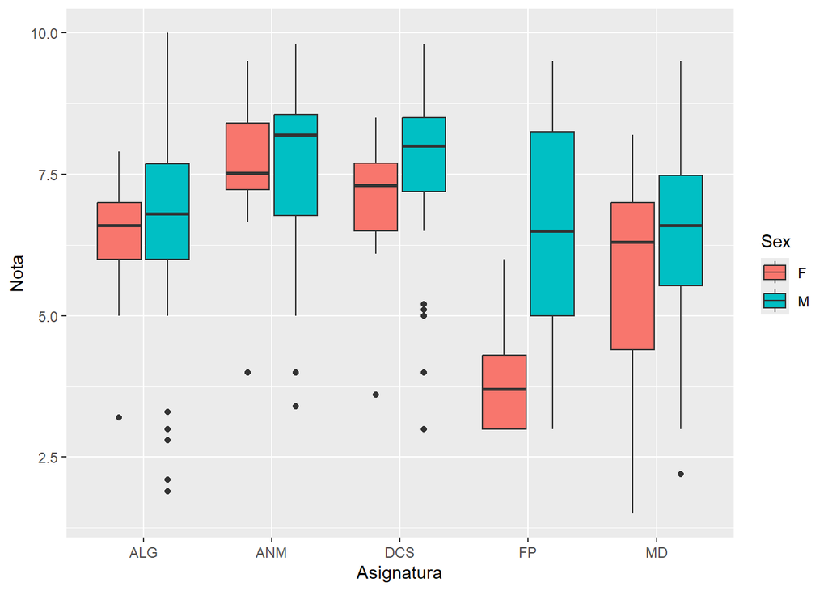

```r
pivot_longer(notas, cols = names(notas[,14:18]),
               names_to = "Asignatura",
               values_to = "Nota") %>%
  ggplot(aes(Asignatura, Nota, fill = Sex)) +
  geom_boxplot()
```

# 11. Selecciona los alumnos que tengan calificaciones en todas las asignaturas y represéntalas gráficamente. En el eje X aparecerá el usuario del alumno (girado 90º) y en el eje Y la calificación numérica con un color distinto para cada asignatura. Se mostrará un diagrama de líneas, que una las calificaciones de una misma asignatura para todos los alumnos así como un punto, por asignatura (del mismo color que las líneas), para cada asignatura y alumno.

```r
names(notas)
```

```
##  [1] "Registro"            "FechaNac(DD-MM-YYY)" "Id"
##  [4] "Age"                 "Sex"                 "Wr.Hnd"
##  [7] "NW.Hnd"              "Fold"                "Pulse"
## [10] "Clap"                "Exer"                "Smoke"
## [13] "Height"              "ALG"                 "ANM"
## [16] "FP"                  "DCS"                 "MD"
## [19] "HSt"                 "Hwork"               "Comentarios"
```

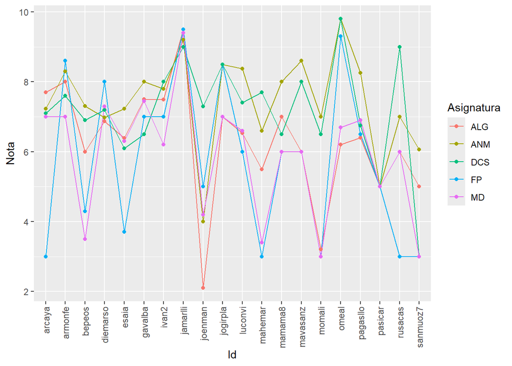

```r
alumnos <- notas %>% select(Id, ALG, ANM, FP, DCS, MD) %>% filter(complete.cases(.))
col_nota<- alumnos %>% pivot_longer(cols = c(ALG, ANM, FP, DCS, MD),
                                    names_to= "Asignatura",
                                    values_to = "Nota")


col_nota %>%
  # group = Asignatura así une puntos en líneas
  ggplot(aes(x = Id, y = Nota, color = Asignatura, group = Asignatura)) +
  geom_line() +
  geom_point() +
  theme(axis.text.x = element_text(angle = 90, vjust = 0.5, hjust = 1))
```

```r
fich2<-read_tsv("./data/NosAutoanalizamos2026 - NosAutoanalizamos.tsv")
```

```
## ──────────────────────────────────────────────────────── Delimiter: "\t" chr
## (22): ...1, ...2, ...3, Fecha, 04-01-2006, ...6, ...7, ...8, ...9, ...10... lgl
## (1): ...22
```

```r
df2<-as.data.frame(fich2)



# Realizamos el mismo proceso:
# Seleccionamos desde la fila 25 hasta el final:
datos2<- df2[24:nrow(df2),]
colnames(datos2)<- datos2[2,]
datos2<-datos2[-(1:3),] #Quitamos la fila 24, 25 y 26

head(datos2)
```

```
##    FechaNac(DD-MM-YYY)      Id Age Sex Wr.Hnd    NW.Hnd      Fold Pulse
## 27          11-03-2004  sorivi  21   F   16,6   Derecha   Derecho    68
## 28          11-03-2006 magiflo  19   M     20   Derecha   Derecho    59
## 29          18-09-2006 fuenar2  19   F     20   Derecha Izquierdo    60
## 30          04-12-2006 lauhori  19   F     20   Derecha Izquierdo    60
## 31           31-7-2007 Jorica3  18   M   18.8 Izquierda   Derecha    68
## 32          05-12-2006  bevili  19   F     20   Derecha Izquierdo    60
##         Clap Exer Smoke Height  ALG  ANM   FP  DCS   MD HSt Hwork       DNI
## 27 Izq s Der    3    No    156   NC  7,9   NC    9  7,8 3,5    28 23886807L
## 28 Der s Izq    6    No    173   NC <NA>   NC <NA>  6,2   3     0 74395855D
## 29 Der s Izq    5    No    170 <NA> <NA> <NA> <NA> <NA>   2     0 49849495P
## 30 Der s Izq    4    No    180 <NA> <NA> <NA> <NA> <NA>   3     0 32735426D
## 31   Ninguna    6    No    184  3.4  7.6 <NA>    5    5   2    30 54414483W
## 32 Der s Izq    0    No    169  3,2  6,9 <NA>    4    4   4     0 53885132L
##                                                                                                                                    Comentarios
## 27                                                                                 Tratamiento de los Datos parece una asignatura interesante.
## 28 Tratamiento de Datos es importante para poder preparar conjuntos de datos para luego trabajar con ellos y poder sacar información de ellos.
## 29                                                    Espero aprobar por fin esta asignatura. Esta asignatura es muy relevate para la carrera.
## 30                                                                         Tratamiento de datos es una asignatura que requiere trabajo diario.
## 31                                                De momento, tratamiento de datos es la asignatura a la que más me interesa del cuatrimestre.
## 32                                                                                                         Tratamiento de datos es muy Teorico
##    NA <NA>
## 27 NA <NA>
## 28 NA <NA>
## 29 NA <NA>
## 30 NA <NA>
## 31 NA <NA>
## 32 NA <NA>
```

```r
# Cambiamos el nombre de la columna
colnames(datos2)[1] <- "FechaNac"
```

# 12. Sin hacer ninguna modificación en el código utiliza el fichero correspondiente al año 2026 y compara los resultados con los del curso 2022

```r
col_nota2 <- datos2 %>%
  select(Id, ALG, ANM, FP, DCS, MD) %>%
  filter(complete.cases(.)) %>%
  mutate(across(c(ALG, ANM, FP, DCS, MD), as.numeric)) %>%
  pivot_longer(cols = c(ALG, ANM, FP, DCS, MD),
               names_to = "Asignatura",
               values_to = "Nota") %>%
  mutate(Curso = "2026")
col_nota2
```

```
## # A tibble: 75 × 4
##    Id      Asignatura  Nota Curso
##    <chr>   <chr>      <dbl> <chr>
##  1 sorivi  ALG           NA 2026
##  2 sorivi  ANM           NA 2026
##  3 sorivi  FP            NA 2026
##  4 sorivi  DCS            9 2026
##  5 sorivi  MD            NA 2026
##  6 diazrua ALG           NA 2026
##  7 diazrua ANM           NA 2026
##  8 diazrua FP             8 2026
##  9 diazrua DCS            8 2026
## 10 diazrua MD             7 2026
## # ℹ 65 more rows
```

```r
c<-col_nota %>% mutate(Curso= "2022")
c
```

```
## # A tibble: 100 × 4
##    Id       Asignatura  Nota Curso
##    <chr>    <chr>      <dbl> <chr>
##  1 jamarlli ALG         9.5  2022
##  2 jamarlli ANM         9.2  2022
##  3 jamarlli FP          9.5  2022
##  4 jamarlli DCS         9    2022
##  5 jamarlli MD          9.4  2022
##  6 esaia    ALG         6.39 2022
##  7 esaia    ANM         7.23 2022
##  8 esaia    FP          3.7  2022
##  9 esaia    DCS         6.1  2022
## 10 esaia    MD          6.3  2022
## # ℹ 90 more rows
```

```r
# Unimos los df para hacer la grafica
total<- bind_rows(col_nota2, c)
head(total)
```

```
## # A tibble: 6 × 4
##   Id      Asignatura  Nota Curso
##   <chr>   <chr>      <dbl> <chr>
## 1 sorivi  ALG           NA 2026
## 2 sorivi  ANM           NA 2026
## 3 sorivi  FP            NA 2026
## 4 sorivi  DCS            9 2026
## 5 sorivi  MD            NA 2026
## 6 diazrua ALG           NA 2026
```

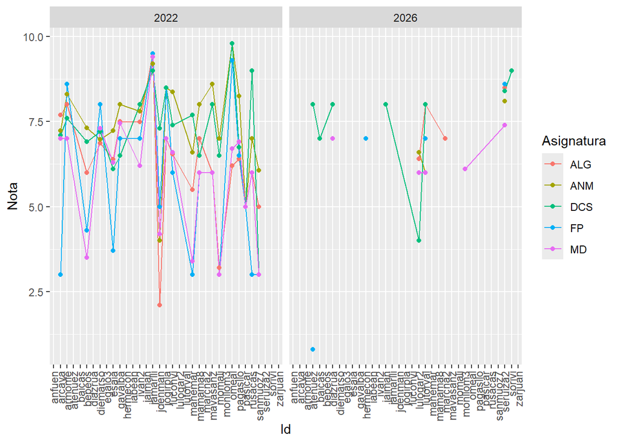

```r
total %>%
  ggplot(aes(x = Id, y = Nota, color = Asignatura, group = Asignatura)) +
  geom_line() +
  geom_point() +
  facet_wrap(~Curso) +
  theme(axis.text.x = element_text(angle = 90, vjust = 0.5, hjust = 1))
```

# 13. Responde a las siguientes preguntas, utilizando los datos del curso 2026. Ten en cuenta que deberás hacer correcciones en los datos en aquellos casos en los que los valores introducidos contengan errores. Por ejemplo si en las instrucción se indica que para el sexo de nacimiento los valores posibles son M y F, cualquier otro valor deberá ser corregido. Si la corrección no es posible sustituye por NA. Debes justificar todas las cuestiones con los datos disponibles.

1. ¿Qué edad, expresada en años (con decimales) tiene el alumno más joven a fecha 01/02/2026.

```r
names(datos2)
```

```
##  [1] "FechaNac"    "Id"          "Age"         "Sex"         "Wr.Hnd"
##  [6] "NW.Hnd"      "Fold"        "Pulse"       "Clap"        "Exer"
## [11] "Smoke"       "Height"      "ALG"         "ANM"         "FP"
## [16] "DCS"         "MD"          "HSt"         "Hwork"       "DNI"
## [21] "Comentarios" "NA"          NA
```

```r
head(datos2)
```

```
##      FechaNac      Id Age Sex Wr.Hnd    NW.Hnd      Fold Pulse      Clap Exer
## 27 11-03-2004  sorivi  21   F   16,6   Derecha   Derecho    68 Izq s Der    3
## 28 11-03-2006 magiflo  19   M     20   Derecha   Derecho    59 Der s Izq    6
## 29 18-09-2006 fuenar2  19   F     20   Derecha Izquierdo    60 Der s Izq    5
## 30 04-12-2006 lauhori  19   F     20   Derecha Izquierdo    60 Der s Izq    4
## 31  31-7-2007 Jorica3  18   M   18.8 Izquierda   Derecha    68   Ninguna    6
## 32 05-12-2006  bevili  19   F     20   Derecha Izquierdo    60 Der s Izq    0
##    Smoke Height  ALG  ANM   FP  DCS   MD HSt Hwork       DNI
## 27    No    156   NC  7,9   NC    9  7,8 3,5    28 23886807L
## 28    No    173   NC <NA>   NC <NA>  6,2   3     0 74395855D
## 29    No    170 <NA> <NA> <NA> <NA> <NA>   2     0 49849495P
## 30    No    180 <NA> <NA> <NA> <NA> <NA>   3     0 32735426D
## 31    No    184  3.4  7.6 <NA>    5    5   2    30 54414483W
## 32    No    169  3,2  6,9 <NA>    4    4   4     0 53885132L
##                                                                                                                                    Comentarios
## 27                                                                                 Tratamiento de los Datos parece una asignatura interesante.
## 28 Tratamiento de Datos es importante para poder preparar conjuntos de datos para luego trabajar con ellos y poder sacar información de ellos.
## 29                                                    Espero aprobar por fin esta asignatura. Esta asignatura es muy relevate para la carrera.
## 30                                                                         Tratamiento de datos es una asignatura que requiere trabajo diario.
## 31                                                De momento, tratamiento de datos es la asignatura a la que más me interesa del cuatrimestre.
## 32                                                                                                         Tratamiento de datos es muy Teorico
##    NA <NA>
## 27 NA <NA>
## 28 NA <NA>
## 29 NA <NA>
## 30 NA <NA>
## 31 NA <NA>
## 32 NA <NA>
```

```r
ncol(datos2)
```

```
## [1] 23
```

```r
datos2<-datos2[,-(22:23)]



# Definimos la fecha objetivo
fecha_objetivo <- dmy("01-02-2026")
fecha_objetivo
```

```
## [1] "2026-02-01"
```

```r
datos2$FechaNac <- dmy(datos2$FechaNac)



# Calculamos edad exacta a 01/02/2026
datos2 <- datos2 %>%
  mutate(
    EDAD_decimales = as.numeric(fecha_objetivo - FechaNac) / 365.25) %>% arrange(EDAD_decimales)

head(datos2)
```

```
##     FechaNac      Id Age Sex Wr.Hnd  NW.Hnd      Fold Pulse      Clap Exer
## 1 2007-12-19 gipicar  18   F     19 Derecha   Derecho    71 Der s Izd    2
## 2 2007-12-17 nihesan  18   M     22 Derecha   Derecho    70 Der s Izq    4
## 3 2007-12-14 mapeso5  18   M     19 Derecha Izquierdo    55 Izq s Der    5
## 4 2007-12-03 zarjuan  18   M     18 Derecha   Derecha    54   Derecha    6
## 5 2007-12-03   aceva  18   M     21 Derecha Izquierdo    66 Izq s Der    4
## 6 2007-11-28     a29  18   M     20 Derecha Izquierdo    67 Izq s Der    5
##   Smoke Height ALG ANM   FP DCS  MD HSt Hwork       DNI
## 1    No    157 7,2   6 <NA>   4 6,2   3     0 73664304L
## 2    No    182 7.5 8,1 <NA>  NC 6,4   2     0 54290706B
## 3    No    179  NC  NC <NA>   4 5,7   2     0 23888492W
## 4    No    185  NC 7,4   NC  NC 7,3   0     0 54748087Z
## 5    No    175 5,4  10 <NA> 5,2 7,3   4     8 46275240E
## 6    No    172 6,8 6,3 <NA> 7,6 6,6   1     3 54290100A
##                                                                                                                                                                                                                                                   Comentarios
## 1                                                                                                                                                                                                                     Espero que no sea tan teórica como DCS.
## 2                                                                                                                                                                                                                                 Por lo pronto mejor que dcs
## 3                                                                                                                                                                                                            De momento me esta gustando, confio en aprobarla
## 4                                                                                         Tratamiento de datos es lo mejor del mundo, siempre soñé con tener una asignatura como tratamiento de datos, es mi sueño desde pequeño. !VIVA TRATAMIENTO DE DATOS¡
## 5 Tiene muy buena pinta. Espero no arrepentirme de pensar que esto puede llegar a ser "fácil" y "divertido", porque aunque de momento es así, estoy seguro de que en algún momento esta asignatura me provocará una gran pérdida de cabello y horas de sueño.
## 6                                                                                                                                                       Esta asignatura parece que va a estar enfocada a lo que vamos a hacer en la vida real y eso está bien
##   EDAD_decimales
## 1       18.12183
## 2       18.12731
## 3       18.13552
## 4       18.16564
## 5       18.16564
## 6       18.17933
```

```r
#La edad del usuario más joven es 18.12183
```

2. Cuántos alumnos simultanean trabajo y estudios.

```r
names(datos2)
```

```
##  [1] "FechaNac"       "Id"             "Age"            "Sex"
##  [5] "Wr.Hnd"         "NW.Hnd"         "Fold"           "Pulse"
##  [9] "Clap"           "Exer"           "Smoke"          "Height"
## [13] "ALG"            "ANM"            "FP"             "DCS"
## [17] "MD"             "HSt"            "Hwork"          "DNI"
## [21] "Comentarios"    "EDAD_decimales"
```

```r
datos2$Hwork<-as.numeric(datos2$Hwork)


t_e<- datos2 %>% filter(Hwork>0) %>% distinct()
nrow(t_e) # 14 alumnos realizan trabajos y estudios
```

```
## [1] 14
```

3. Hay más hombres o más mujeres fumadoras.

```r
fumadores<- datos2 %>% filter(Smoke==  "Si")
fumadores
```

```
##     FechaNac       Id Age Sex Wr.Hnd    NW.Hnd      Fold Pulse      Clap Exer
## 1 2007-06-03  marlau6  18   M     20   Derecha Izquierdo    60 Izq s Der    4
## 2 2007-03-31   isago2  18   M     22   Derecha Izquierdo    65 Der s Izq    3
## 3 2007-03-30 antanuez  18   M     20 Izquierda   Derecho    59 Izq s Der    3
## 4 2007-02-22 majuanm4  19   M     19   Derecha   Derecho    60 Der s Izq    5
## 5 2006-11-01 seruiza2  19   M     19 Izquierda Izquierda    69 Izq s Der    0
## 6 2006-07-20   anfuen  19   M     20   Derecha   Derecho    65 Der s Izq    3
## 7 2002-12-02    amirt  23   M     18 Izquierda Izquierda    70 Izq s Der    3
##   Smoke Height  ALG  ANM   FP  DCS   MD HSt Hwork       DNI
## 1    Si    185  7,5  6,5 <NA>  8,2  7,8   2     0 20986029R
## 2    Si    181  2.5  4.7 <NA>    6  7.5   3     0 73599010E
## 3    Si    182   NC   NC <NA>    8  7,5 0,5     9 53885739M
## 4    Si    175  8,8  7,3 <NA>  7,5  7,5 0,5    15 54015599F
## 5    Si    174  8.5  8.1  8.6  8.4  7.4   4     0  5459375P
## 6    Si    178   NC   NC   NC   NC   NC   2     0 20869026E
```

[output cut: 17 more lines]

```r
table(fumadores$Sex)
```

```
##
## M
## 7
```

```r
# Vemos que solo hay hombres fumadores.
```

4. Cuál es el valor medio y la varianza de la variable Wr.Hnd según el sexo.

```r
str(datos2)
```

```
## 'data.frame':    61 obs. of  22 variables:
##  $ FechaNac      : Date, format: "2007-12-19" "2007-12-17" ...
##  $ Id            : chr  "gipicar" "nihesan" "mapeso5" "zarjuan" ...
##  $ Age           : chr  "18" "18" "18" "18" ...
##  $ Sex           : chr  "F" "M" "M" "M" ...
##  $ Wr.Hnd        : chr  "19" "22" "19" "18" ...
##  $ NW.Hnd        : chr  "Derecha" "Derecha" "Derecha" "Derecha" ...
##  $ Fold          : chr  "Derecho" "Derecho" "Izquierdo" "Derecha" ...
##  $ Pulse         : chr  "71" "70" "55" "54" ...
##  $ Clap          : chr  "Der s Izd" "Der s Izq" "Izq s Der" "Derecha" ...
##  $ Exer          : chr  "2" "4" "5" "6" ...
##  $ Smoke         : chr  "No" "No" "No" "No" ...
##  $ Height        : chr  "157" "182" "179" "185" ...
##  $ ALG           : chr  "7,2" "7.5" "NC" "NC" ...
##  $ ANM           : chr  "6" "8,1" "NC" "7,4" ...
##  $ FP            : chr  NA NA NA "NC" ...
##  $ DCS           : chr  "4" "NC" "4" "NC" ...
##  $ MD            : chr  "6,2" "6,4" "5,7" "7,3" ...
##  $ HSt           : chr  "3" "2" "2" "0" ...
##  $ Hwork         : num  0 0 0 0 8 3 0 0 25 0 ...
##  $ DNI           : chr  "73664304L" "54290706B" "23888492W" "54748087Z" ...
##  $ Comentarios   : chr  "Espero que no sea tan teórica como DCS." "Por lo pronto mejor que dcs" "De momento me esta gustando, confio en aprobarla" "Tratamiento de datos es lo mejor del mundo, siempre soñé con tener una asignatura como tratamiento de datos, es"| __truncated__ ...
##  $ EDAD_decimales: num  18.1 18.1 18.1 18.2 18.2 ...
```

```r
datos2$Wr.Hnd<-as.numeric(datos2$Wr.Hnd)
wr<- datos2 %>% group_by(Sex)%>%
  summarise(
    Media= mean(Wr.Hnd, na.rm=TRUE),
    Varianza= var(Wr.Hnd, na.rm=TRUE)
  )


wr
```

```
## # A tibble: 3 × 3
##   Sex   Media Varianza
##   <chr> <dbl>    <dbl>
## 1 Exer  NaN      NA
## 2 F      18.3     4.20
## 3 M      20.0     1.78
```

5. Determina si existe relación entre el sexo y la mano con la que se escribe (NW.Hnd)

```r
# Son dos variables categóricas, entonces podemos utilizar varias

datos2$NW.Hnd <- tolower(datos2$NW.Hnd)

chisq.test(datos2$Sex, datos2$NW.Hnd)
```

```
##
##  Pearson's Chi-squared test with Yates' continuity correction
##
## data:  datos2$Sex and datos2$NW.Hnd
## X-squared = 0.65904, df = 1, p-value = 0.4169
```

```r
# Vemos que  p-value = 0.4169, por tanto aceptamos la hipótesis de que son independientes.
```

6. Existe una relación lineal entre la altura (Height) y la distancia del extremo del meñique al extremo del pulgar de la mano con la que escribimos (Wr.Hnd)

```r
datos2$Height<-as.numeric(datos2$Height)

datos2$Wr.Hnd<-as.numeric(datos2$Wr.Hnd)

cor(datos2$Height, datos2$Wr.Hnd, use= "complete.obs", method= "pearson")
```

```
## [1] 0.3407237
```

```r
# Nos da 0.3407237, y vemos que sí que existe pero no es tan fuerte.
```

g.El identificador de Hampel detecta algún outlier en la variable altura.

```r
madm <- function(x, na.rm=T) {
  1.4826*median(abs(x-median(x, na.rm = na.rm)), na.rm = na.rm)}

# Identificador Hampel
reglahampel <- function(x) {
  #Calcula la mediana y la MADM (Median Absolute Deviation from the Median),
  #excluyendo NA.
  median_x <- median (x, na.rm = TRUE)
  mad_m <- madm(x)
  #Calculamos el límite superior e inferior.
  upper_limit <- median_x + 3 * mad_m
  lower_limit <- median_x - 3 * mad_m
  #Identificamos los outliers
  outliers1 <- x > upper_limit | x < lower_limit
  return (outliers1)}


reglahampel(datos2$Height)
```

```
##  [1] FALSE FALSE FALSE FALSE FALSE FALSE FALSE FALSE FALSE FALSE FALSE FALSE
## [13] FALSE FALSE FALSE FALSE FALSE FALSE FALSE FALSE FALSE FALSE FALSE FALSE
## [25] FALSE FALSE FALSE FALSE FALSE FALSE FALSE FALSE FALSE FALSE FALSE FALSE
## [37] FALSE FALSE FALSE FALSE FALSE FALSE FALSE FALSE FALSE FALSE FALSE FALSE
## [49] FALSE FALSE FALSE FALSE FALSE FALSE FALSE FALSE FALSE FALSE FALSE FALSE
## [61]    NA
```

```r
# Vemos que no existe ningún outliers en la variable "Height".
```

8. Considera la asignatura FP. Si queremos realizar una imputación generalizada usando la media, ¿qué valor deberíamos utilizar ?

```r
#Sustituir los valores faltantes por la media de FP.

datos2$FP<-as.numeric(datos2$FP)
media_FP<-mean(datos2$FP, na.rm=TRUE)
media_FP
```

```
## [1] 6.28
```

```r
Imp<- datos2 %>% filter(is.na(FP))

# imputación por la media
Imputacion_datos2 <- datos2 %>%
  mutate(FP = ifelse(
      is.na(FP),
      media_FP,
      FP
    ))



any(is.na(Imputacion_datos2$FP))
```

```
## [1] FALSE
```

1. Define una nueva variable (PulseCat) a partir del ritmo cardíaco (Pulse), con dos valores PulseH, si Pulse>=65 y PulseL si Pulse<65. ¿Qué valores utilizarías para imputar los valores faltantes de las notas de FP, dependiendo del valor de PulseCat (imputación por casos similares)

```r
datos2$Pulse <- as.numeric(datos2$Pulse)

Pulse<-datos2%>% mutate(
  PulseCat= if_else(
    Pulse >= 65,
    "PulseH",
    "PulseL"))


# Valores de imputación por grupo
imputacion_FP <- Pulse %>%
  group_by(PulseCat) %>%
  summarise(
    media_FP = mean(FP, na.rm = TRUE))


imputacion_FP
```

```
## # A tibble: 3 × 2
##   PulseCat media_FP
##   <chr>       <dbl>
## 1 PulseH       7.8
## 2 PulseL       5.27
## 3 <NA>       NaN
```

```r
# La media de las notasd de FP de cada valor segun tengan PulseH o PulseL
```

10. ¿Qué podemos decir, como científicos de datos, ante esta frase referida a nuestros datos ? “El ritmo cardíaco está ligado con la cantidad de sangre que llega al cerebro, por tanto existirá una relación lineal directa esta esta variable y las calificaciones obtenidas en ALG”

```r
# 2 variables numéricas.

class(datos2$Pulse)
```

```
## [1] "numeric"
```

```r
class(datos2$ALG)
```

```
## [1] "character"
```

```r
datos2$ALG<- as.numeric(datos2$ALG)
# Utilizamos la correlación de Pearson o de Speraman.
cor(datos2$Pulse, datos2$ALG, use="complete.obs", method= "spearman")
```

```
## [1] 0.2784835
```

Vemos que es una relación positiva pero muy cercana a 0, por tanto no podemos afirmar que exita una relación directa entre estas dos variables.